# Checkpoint05: **DOCUMENTACIÓN DE PYTHON**

## Full Stack Development Course

### Autora: **M. Alexandra Dodu**

# Índice

1. ¿Qué es una condicional?

2. ¿Cuáles son los diferentes tipos de bucles en Python? ¿Por qué son útiles?

3. ¿Qué es una lista por comprensión en Python?

4. ¿Qué es un argumento en Python?

5. ¿Qué es una función Lambda en Python?

6. ¿Qué es un paquete pip?

# 1. ¿Qué es una condicional?

## 1.1. Definición

Una condicional en Python es una estructura de control de flujo que permite tomar decisiones basadas en condiciones específicas. Estas condiciones se evalúan como verdaderas o falsas y, dependiendo del resultado, se ejecuta un bloque de código u otro.

## 1.2. Tipos de condicionales

Podríamos catalogar las condicionales en tres tipos: simples, compuestas y anidadas. Vamos a ir viendo ahora cada una de ellas para entenderlas.

### 1.2.1. Estructura condicional simple

Las condicionales simples se emplean para ejecutar un conjunto de instrucciones **solamente si se cumple una condición determinada**. Podemos observar en el esquema que el rombo representa la condición y tenemos dos opciones que podemos tomar. Si la condición devuelve un resultado verdadero, ejecutará las opciones que se encuentren en su interior. Si, por el contrario, es falso, no realizará dicha acción.

[figure not shown]

#### Sintaxis

Para la sintaxis de una condicional simple se emplea la sentencia `if`. El condicional `if` se utiliza para ejecutar un bloque de código si una condición es verdadera. Después de la sentencia if, se añaden **dos puntos `:`** y, en la siguiente línea, hay que añadir **indentación**.

```
if <condición>:
    <bloque_de_código_con_indentación>
```

#### Ejemplo

En este primer ejemplo, podemos observar que, al ser la edad de 23 menor que 26, se imprime por pantalla que puede acceder a solicitar el Carnet Joven. Observar la sintaxis con los dos puntos y la indentación.

```python
edad = 23
if edad < 26:
    print("Puedes acceder a solicitar el Carnet Joven.")
```

```
Puedes acceder a solicitar el Carnet Joven.
```

Sin embargo, en este otro ejemplo, en el cual no se cumple la edad, puesto que 26 no es menor que 26, sino igual, no se imprime nada.

```python
edad = 26
if edad < 26:
    print("Puedes acceder a solicitar el Carnet Joven.")
```

Por tanto, sólo se realiza una acción cuando la condición es verdadera. Cuando es falsa, no se toma ninguna acción. Pero, ¿cómo podemos tomar decisiones cuando estamos en este último caso? Pasemos al siguiente tipo de condicional.

### 1.2.2. Estructura condicional compuesta

Las condicionales compuestas se emplean para ejecutar un conjunto de instrucciones **cuando hay múltiples condiciones que deben evaluarse**. Si ahora nos fijamos en el esquema, vemos que podemos tomar decisiones cuando la condición es falsa.

[figure not shown]

#### Sintaxis

Se emplea la sentencia `if` junto con la sentencia `else`. El condicional `else` se utiliza para ejecutar un bloque de código si ninguna de las condiciones anteriores se cumple. Aquí también se añaden dos puntos `:` después de la condicional y la indentación en las siguientes líneas, con las instrucciones a realizar.

```
if <condición>:
    <bloque_de_código_con_indentación>
else:
    <bloque_de_código_con_indentación>
```

#### Ejemplo

Siguiendo con el ejemplo anterior, en este caso se imprime por pantalla un mensaje cuando la edad no es menor de 26 años:

```python
edad = 26
if edad < 26:
    print("Puedes acceder a solicitar el Carnet Joven.")
else:
    print("Lo siento, no puedes acceder a solicitar el Carnet Joven.")
```

```
Lo siento, no puedes acceder a solicitar el Carnet Joven.
```

### 1.2.3. Estructuras condicionales anidadas

Las condicionales anidadas se emplean cuando nos interese que una condicional esté dentro de otra, es decir, tomar decisiones dentro de otras decisiones. Se pueden incluir condicionales simples o compuestas dentro de ellas, como se puede observar en el siguiente esquema. La principal condición que podemos ver es una estructura compuesta y la segunda condición es en este caso, una estructura simple.

Es común que se representen este tipo de condiciones anidadas aunque esto es un simple ejemplo en comparación con lo que se puede ver normalmente en cualquier código.

[figure not shown]

#### Sintaxis

En cuanto a su sintaxis, además de las condicionales `if` y `else`, se puede emplear el condicional `elif`. El condicional `elif` se utiliza para evaluar múltiples condiciones después de la primera condición `if`. Si la primera condición no se cumple, se evalúa la siguiente condición con `elif`.

La condicional `elif`se puede emplear tantas veces se requiera, sin embargo, la condicional `else` es opcional.

**¡Recordar los dos puntos después de la condición y la indentación en el código!**

```
if <condición>:
    <bloque_de_código_con_indentación>
elif <condición>:
    <bloque_de_código_con_indentación>
else:
    <bloque_de_código_con_indentación>
```

#### Ejemplo

Vamos a imaginar que somos una profesora de la asignatura de "Programación en Python" y hemos realizado tres exámenes a una alumna. Para saber si la alumna tiene Sobresaliente, Notable, Aprobado o Suspenso, se genera un bloque de código. Primero, se realiza un promedio de las notas y, segundo, unas condicionales para determinar el rango de nota.

```python
nota1 = 10
nota2 = 4
nota3 = 8

promedio_notas = (nota1 + nota2 + nota3) / 3 # en este caso, el promedio es de 7,3333

if promedio_notas < 5:
    print("Suspenso")
else:
    if promedio_notas < 7:
        print("Aprobado")
    elif promedio_notas < 8.9 and promedio_notas >= 7:
        print("Notable")
    else:
        print("Sobresaliente")
```

```
Notable
```

En este ejemplo se hace uso del operador lógico `and`. Si quieres saber más sobre los operadores lógicos, te recomiendo [el apartado sobre ello](https://ellibrodepython.com/operadores-logicos) del blog El libro de Python. Sobre operadores en general, en el mismo blog tienes [este otro apartado](https://ellibrodepython.com/operadores-python).

## 1.3. ¡Pon en práctica lo aprendido!

Te propongo unos pocos retos para que vayas propando por mismo/a/e. Puedes utilizar [Google Colab](https://colab.research.google.com/?hl=es) para implementar tu código y comprobar que funciona sin errores. Más adelante te proporciono las soluciones para que corrijas si es necesario. ¡Suerte!

**Reto 1.**Escribe un programa que solicite al usuario ingresar una contraseña. Si la contraseña ingresada es "secreta123", imprime "Acceso concedido", de lo contrario, imprime "Contraseña incorrecta".

**Reto 2.**Escribe un programa que solicite al usuario ingresar una temperatura en grados Celsius y luego imprima una categorización de la temperatura en base a los siguientes criterios: "Frío" si la temperatura es menor que 10 grados, "Normal" si la temperatura está entre 10 y 25 grados, y "Caliente" si la temperatura es mayor o igual a 25 grados.

### Soluciones

```python
# Solución Reto 1
contraseña = input("Ingresa tu contraseña: ")
if contraseña == "secreta123":
    print("Acceso concedido")
else:
    print("Contraseña incorrecta")
```

```
Contraseña incorrecta
```

```python
# Solución Reto 2
temperatura = int(input("Ingresa la temperatura en grados Celsius: "))
if temperatura < 10:
    print("Frío")
elif temperatura >= 10 and temperatura < 25:
    print("Normal")
else:
    print("Caliente")
```

```
Normal
```

¡Espero que te hayan ayudado a asimilar lo aprendido sobre las condicionales!

## 1.4. Bibliografía para profundizar

Si tienes interés en ahondar más en las condicionales en Python, te recomiendo estos enlaces:

- [El Libro de Python](https://ellibrodepython.com/if-python#condicional-en-python)
- [Aprende Python](https://aprendepython.es/core/controlflow/conditionals/)

# 2. ¿Cuáles son los diferentes tipos de bucles en Python? ¿Por qué son útiles?

## 2.1. Definición

En programación, un bucle es una construcción que permite ejecutar un bloque de código varias veces de manera controlada. Es decir, ejecutar un código repetidamente tantas veces como la condición se mantenga verdadera.

¿Te imaginas tener que escribir de 1 al 1000, número a número? Un bucle nos permite hacerlo rápidamente, ¡sin tener que sufrir!

[figure not shown]

## 2.2. Tipos de bucles

Los bucles más comunes son los bucles `for`y `while`. Vamos a ir viendo cada uno de ellos y en qué se diferencian.

### 2.2.1. Bucle `for`

Este bucle se utiliza para iterar sobre una secuencia (como una lista, una tupla, un diccionario, etc.) o cualquier objeto iterable **dado un número conocido de veces**. Itera sobre cada elemento de la secuencia en orden y ejecuta el bloque de código dentro del bucle para cada elemento.

El bucle `for` permite realizar una acción teniendo en cuenta un iterable (definición en el apartado de Sintaxis). Cuando ya no queden elementos con los cuales iterar, el bucle se romperá. Esto se puede ver representado en el siguente diagrama:

[figure not shown]

#### Sintaxis

Antes de nada, procedo a definiros un concepto clave: un iterable.

- En Python, un **iterable** es cualquier objeto que pueda ser iterado, es decir, que se pueda recorrer elemento por elemento. Esto incluye objetos como listas, tuplas, diccionarios, conjuntos y cadenas de caracteres.

Así, el bucle `for` se emplea sobre iterables.

En cuanto a su sintaxis, se añade la palabra reservada `for`, espacio en blanco, nombre de la variable que va a iterar (el que queramos), espacio en blanco, palabra reservada `in`, espacio en blanco, el iterable y dos puntos, como en las condiciones. Además, también se tiene que tener en cuenta la indentación en las siguientes líneas del bucle, ¡muy importante! Además, cuando nos interese romper el bucle (cuando se haya cumplido una determinada condición), podemos emplear la palabra reserva `break`.S

```
for <variable> in <iterable>:
    <bloque_de_código_con_indentación>
    break
```

#### Ejemplos

**Ejemplo 1.** Imaginar que tenemos una lista con nombres y nos interese imprimirlas por pantalla, de una en una y además, contar el número de letras que tiene cada palabra:

```python
frutas = ["manzana", "banana", "cereza"]
for i in frutas:
    print(i, len(i))
```

```
manzana 7
banana 6
cereza 6
```

```python
for num in range(1,21):
    print(num)
```

```
1
2
3
4
5
6
7
8
9
10
11
12
13
14
15
16
17
18
19
20
```

**Ejemplo 3.** Ahora he generado un código que itera sobre un diccionario llamado `bases_nitrogenadas`. En cada iteración, imprimirá las bases nitrogenadas asociadas a cada tipo de ácido nucleico (ADN o ARN).

```python
bases_nitrogenadas = {
    'ADN' : [ 'adenina', 'citosina', 'guanina', 'timina' ],
    'ARN' : [ 'adenina', 'citosina', 'guanina', 'uracilo' ],
    }

for clave, valor in bases_nitrogenadas.items():
  print(f'Bases nitrogenadas del {clave}:', valor)
```

```
Bases nitrogenadas del ADN: ['adenina', 'citosina', 'guanina', 'timina']
Bases nitrogenadas del ARN: ['adenina', 'citosina', 'guanina', 'uracilo']
```

### 2.2.2. Bucle `while`

El bucle `while` se utiliza para **repetir un bloque de código mientras se cumpla una condición específica**. El bucle `while` continuará ejecutando el bloque de código siempre y cuando la condición sea verdadera, como se puede apreciar en el siguiente diagrama:

[figure not shown]

Cuando la condición es falsa, el bucle se rompe. Por ejemplo, imaginar que una mujer está conduciendo, pero tiene que parar cuando un obstáculo choca su coche. La sentencia sería algo así como: "mientras el coche no se vea golpeado por un obstáculos, conduce". Por tanto, cuando una roca choque el automóvil, ¿qué va a hacer el coche? Parar.

[figure not shown]

#### Sintaxis

En cuanto a su sintaxis, primero se escribe la palabra reservada `while`, espacio en blanco, la condición y dos puntos. Nuevamente, en el bloque de código se añade indexación.

```
while <condición>:
    <bloque_de_código_con_indentación>
```

#### Ejemplos

**Ejemplo 1.** Vamos a imprimir de 0 al 20, pero ahora con bucle `while`:

```python
contador = 0
while contador < 21:
    print(contador)
    contador += 1
```

```
0
1
2
3
4
5
6
7
8
9
10
11
12
13
14
15
16
17
18
19
20
```

**Ejemplo 2.** También podemos imprimir los números al revés, de 20 a 1:

```python
nums = list(range(1, 21))

while len(nums) > 0:
  print(nums.pop())
```

```
20
19
18
17
16
15
14
13
12
11
10
9
8
7
6
5
4
3
2
1
```

**Ejemplo 3.** Como curiosidad, por si te apetece imprimir infinitamente algo:

```python
# Mejor si no ejecutas esto
while True:
    print("Bucle infinito")
```

### 2.2.3. Diferencias entre los bucles `for`y `while`

El `for` es un tipo de bucle parecido al `while`, pero con ciertas diferencias. La principal es que el número de iteraciones de un `for` esta definido de antemano, mientras que en un `while` no. La diferencia principal con respecto al `while` es en la condición. Mientras que en el `while` la condición era evaluada en cada iteración para decidir si volver a ejecutar o no el código, en el `for` no existe tal condición, sino un iterable que define las veces que se ejecutará el código.

## 2.3. ¡Pon en práctica lo aprendido!

Te voy a proponer unos retos para que vayas asentando lo que has aprendido de los bucles. Cabe mencionar que las soluciones que luego te proporciono son posibles soluciones, ya que, la magia de la programación es que es posible llegar al mismo punto, pero por diferente camino.

**Reto 1.** Escribe un programa que imprima cada carácter de la cadena 'Python' en líneas separadas.

**Reto 2.** Escribe un programa que calcule la suma de los primeros 10 números naturales.

**Reto 3.** Escribe un programa que solicite al usuario ingresar un número positivo y luego imprima todos los números desde 1 hasta ese número.

### Posibles soluciones

```python
# Solución Reto 1
cadena = "Python"

for caracter in cadena:
    print(caracter)
```

```
P
y
t
h
o
n
```

```python
# Solución Reto 2
suma = 0

for num in range(1, 11):
    suma += num

print(f"La suma de los primeros 10 números naturales es: {suma}")
```

```
La suma de los primeros 10 números naturales es: 55
```

```python
# Solución Reto 3
numero = int(input("Ingresa un número positivo: "))
contador = 1

while contador <= numero:
    print(contador)
    contador += 1
```

```
1
2
3
4
5
```

## 2.4. Bibliografía para profundizar en bucles de Python

- [El libro de Python](https://ellibrodepython.com/estructuras-control-python)
- [Documentación oficial de Python](https://docs.python.org/es/3/tutorial/controlflow.html#for-statements)
- [Diferencias entre bucles for y while](https://www.scaler.com/topics/difference-between-for-and-while-loop-in-python/)

# 3. ¿Qué es una lista por comprensión en Python?

## 3.1. Definición

Una comprensión de lista, también conocida como *list comprehension* en inglés, es una forma concisa y elegante de crear listas en Python, en una sola línea de código. Permite crear listas utilizando una sintaxis más compacta que los bucles `for` tradicionales y utilizando, opcionalmente, usando condicionales `if`.

## 3.2. Uso

Pero, ¿cuándo usar las listas por comprensión?

1. **Transformación de datos**: Cuando necesites transformar los elementos de una lista de una forma específica, como convertir todos los elementos a mayúsculas, multiplicarlos por un valor constante, etc.
2. **Filtrado de datos**: Cuando desees filtrar los elementos de una lista según ciertos criterios, como eliminar elementos que no cumplan con cierta condición o seleccionar solo los elementos que satisfacen ciertos requisitos.
3. **Construcción de listas de forma eficiente**: Las listas por comprensión suelen ser más eficientes y concisas que los bucles `for` tradicionales, por lo que son una buena opción cuando deseas construir listas de manera rápida y clara.
4. **Legibilidad del código**: En muchos casos, una lista por comprensión puede hacer que el código sea más claro y fácil de entender, especialmente cuando se utiliza para operaciones simples y directas en los elementos de una lista.

## 3.3. Sintaxis

La sintaxis sería la siguiente:

```
nueva_lista = [<nombre_expresion> for <variable> in <iterable> [if <condición>]]
```

¿Qué significa cada uno de los componentes?

- `nueva_lista`: Es el nombre de la nueva lista.
- `nombre_expresion`: Es una expresión que define el valor de cada elemento en la lista resultante.
- El segundo componente `for <variable> in <iterable>` sería el correspondiente a un bucle `for`, que acabamos de ver en el apartado anterior.
- El tercer componente `[if <condición>]`, que es opcional, sería el condicional `if`, que hemos visto en el apartado 1.

**Importante** entonces aquí: la lista por comprensión sigue siendo una lista, por tanto, es un tipo de objeto. Por ello, lleva **corchetes `[ ]`** y se almacena en un objeto.

## 3.3. Ejemplos

Esto se ve mejor en la práctica, así que vamos a ir viendo unos ejemplos para entender cómo podemos contruir nuestra lista por comprensión y ahorrarnos dos líneas de código 😜

[figure not shown]

### Ejemplo 1.

Como ya has aprendido cómo emplear un bucle `for`, puedes intentar hacerlo por ti mismo/a/e una vez veas el enunciado. Ello te ayudará a entender mejor cómo se genera una lista por comprensión.

Un ejemplo básico de uso de las listas por comprensión es aplicar una operación sobre un vector. Por ejemplo, añadir una cantidad a todos los elementos de este.

```python
# Método tradicional

numeros = [1, 2, 3, 4]
resultado = []

for n in numeros:
    resultado.append(n + 1)

print(resultado)
```

```
[2, 3, 4, 5]
```

```python
# Con comprensión de listas

numeros = [1, 2, 3, 4]

resultado = [n + 1 for n in numeros]

print(resultado)
```

```
[2, 3, 4, 5]
```

### Ejemplo 2.

Tal como se ha indicado anteriormente es posible añadir condiciones a las listas por comprensión en Python. Siguiendo con el ejemplo anterior, se podría sumar uno solamente a los registros que sean menores que tres.

```python
numeros = [1, 2, 3, 4]

resultado = [n + 1 for n in numeros if n < 3]

print(resultado)
```

```
[2, 3]
```

### Ejemplo 3.

Crea una lista con las letras en mayúsculas de la palabra 'hola'.

```python
palabra = "hola"

mayusculas = [letra.upper() for letra in palabra]

print(mayusculas)
```

```
['H', 'O', 'L', 'A']
```

### Ejemplo 4.

Crea una lista con sólo números pares.

```python
numeros = [2, 3, 7, 8, 10, 12]

pares = [num for num in numeros if num % 2 == 0]

print(pares)
```

```
[2, 8, 10, 12]
```

¡Espero que estos ejemplos te hayan ayudado a aprender cómo generar una lista por comprensión! ¿Quieres ahora poner a prueba lo aprendido? Te voy a preparar unos retos para ello. ¡Suerte!

## 3.4. ¡Por a prueba lo aprendido!

**Reto 1.** Crea una lista con las letras de una palabra mediante una lista por comprensión.

**Reto 2.** Crea una lista de las primeras letras de una lista de palabras.

**Reto 3.** Crea una lista con los todos los múltiples de 2 entre 0 y 10.

### Soluciones

```python
# Solución Reto 1

lista = [letra for letra in 'casa']

print(lista)
```

```
['c', 'a', 's', 'a']
```

```python
# Solución Reto 2

palabras = ["gato", "perro", "oso"]

primeras_letras = [palabra[0] for palabra in palabras]

print(primeras_letras)
```

```
['g', 'p', 'o']
```

```python
# Solución Reto 3

lista = []

lista = [numero for numero in range(0,11) if numero % 2 == 0 ]

print(lista)
```

```
[0, 2, 4, 6, 8, 10]
```

## 3.5. Bibliografía para profundizar

- [List comprehensions (El libro de Python)](https://ellibrodepython.com/list-comprehension-python)
- [Listas por comprensión en Python (Analytics Lane)](https://www.analyticslane.com/2019/09/23/listas-por-comprension-en-python/)
- [Comprensión de listas (Documentación oficial de Python)](https://docs.python.org/es/dev/tutorial/datastructures.html#list-comprehensions)

# 4. ¿Qué es un argumento en Python?

## 4.1. Definición

Los argumentos en Python son los valores que se pasan a una función cuando se la llama. Estos valores se utilizan dentro de la función para realizar operaciones o cálculos.

[figure not shown]

Los argumentos permiten que las funciones sean más flexibles y reutilizables al permitir que se ejecuten con diferentes conjuntos de datos o configuraciones.

El manejo de argumentos en funciones Python es una técnica fundamental que cualquier desarrollador debe conocer. En Python, la flexibilidad y adaptabilidad que ofrecen las funciones en el manejo de argumentos lo convierten en un lenguaje de programación poderoso para el desarrollo de aplicaciones complejas.

## 4.2. Tipos de argumentos

Los argumentos pueden ser de diferentes tipos y se pueden pasar de diferentes maneras a las funciones. Vamos a ver los tipos principales: argumentos posicionales, argumentos de palabra clave, argumentos por defecto y argumentos variables.

### 4.2.1. Argumentos posicionales

Cuando enviamos argumentos a una función, estos se reciben por orden en los parámetros definidos. Se dice, por tanto, que son argumentos por posición.

El uso de argumentos posicionales en Python brinda flexibilidad a las funciones al permitir una llamada más simple y ordenada para una variedad de argumentos. Además, se pueden definir valores por defecto para los argumentos en caso de no ser enviados en la llamada a la función.

Un ejemplo sería:

```python
def resta(a, b):
    return a - b

resta(10, 5)
```

```
5
```

### 4.2.2. Argumentos por palabra clave

Sin embargo, es posible evadir el orden de los parámetros si indicamos durante la llamada que valor tiene cada parámetro a partir de su nombre. Cuando programamos en Python, no solo debemos preocuparnos por la lógica de nuestro código, sino también por su flexibilidad y adaptabilidad. Una de las formas en las que podemos lograr esto es mediante el uso de argumentos con palabras clave.

Los argumentos con palabras clave son una herramienta muy útil en Python para hacer nuestro código más legible y adaptable. Para utilizarlos en nuestras funciones, basta con definir los argumentos de la forma `argumento=valor`. Con esta técnica, podemos hacer que nuestras funciones se adapten a diferentes situaciones sin tener que cambiar su lógica interna.

Por tanto, los argumentos con palabras clave son aquellos que se definen mediante una palabra clave seguida de un signo igual y su valor correspondiente. En el siguiente ejemplo, fijarse en que el orden de los argumentos está cambiado, ahora el argumento `b` va primero.

```python
def resta(a, b):
    return a - b

resta(b=10, a=5)
```

```
-5
```

### 4.2.3. Argumentos por defecto

Al llamar una función que tiene definidos unos parámetros, si no pasamos los argumentos correctamente, dará un error.

```python
resta(5)
```

```
---------------------------------------------------------------------------
TypeError                                 Traceback (most recent call last)
Cell In[26], line 1
----> 1 resta(5)

TypeError: resta() missing 1 required positional argument: 'b'
```

Para solucionarlo, podemos asignar unos valores por defecto a los parámetros. Por tanto, los argumentos por defecto son argumentos que tienen un valor predeterminado en la firma de la función. Si no se proporciona un valor para estos argumentos al llamar a la función, se utiliza el valor predeterminado.

Un ejemplo sería el siguiente. Cuando no se proporciona el valor de `nombre`, la función, por defecto, usará el valor asignado.

```python
def saludar(nombre = 'aprendiz de programación'):
    print(f"Hola, {nombre}. ¡Estás aprendiendo qué es un argumento por defecto!")

saludar()
saludar("Katniss")
```

```
Hola, aprendiz de programación. ¡Estás aprendiendo qué es un argumento por defecto!
Hola, Katniss. ¡Estás aprendiendo qué es un argumento por defecto!
```

#### Mala praxis con argumentos por defecto

**¡CUIDADO!** Es importante tener en cuenta que los valores por defecto solo se evalúan una vez, al definir la función. Esto significa que si se usa un objeto mutable (por ejemplo, una lista o un diccionario) como valor por defecto, se pueden producir resultados inesperados.

En el siguiente ejemplo, se usará una lista como valor predeterminado para el parámetro `lista`:

```python
def agregar_elemento(elemento, lista=[]):
    lista.append(elemento)
    return lista

# Al llamar a esta función sin proporcionar una lista, se utilizará la lista predeterminada
print(agregar_elemento(1))
```

```
[1]
```

Si llamamos a la función de nuevo con un objeto diferente, veremos que ambas llamadas a la función están añadiendo el elemento a la misma lista:

```python
print(agregar_elemento(2))
```

```
[1, 2]
```

Para evitar este comportamiento inesperado, podemos utilizar un valor por defecto que no sea un objeto mutable. Por ejemplo, podemos usar *None* y luego, dentro de la función, creamos la lista o cualquier objeto que deseemos usar.

```python
def agregar_elemento(elemento, lista=None):
    if lista is None:
        lista = []
    lista.append(elemento)
    return lista

print(agregar_elemento(1))
print(agregar_elemento(2))
```

```
[1]
[2]
```

El uso de listas (o cualquier otro objeto mutable) como valor predeterminado en los parámetros de una función en Python se considera una mala práctica por varias razones:

1. **Compartición de estado entre llamadas**: Cuando una lista se utiliza como valor predeterminado, se crea una única instancia de la lista en tiempo de definición de la función. Esto significa que todas las llamadas posteriores a la función compartirán la misma instancia de la lista. Esto puede llevar a resultados inesperados si la lista se modifica en una llamada y los cambios afectan a llamadas posteriores.
2. **Efectos secundarios inesperados**: Debido a la compartición de estado, las modificaciones realizadas en la lista dentro de una llamada pueden persistir entre llamadas subsiguientes, lo que puede conducir a efectos secundarios inesperados y difíciles de depurar.
3. **Dificultad para rastrear el estado**: Al utilizar valores predeterminados mutables, puede resultar difícil rastrear el estado de la función y entender cómo se están modificando los datos a lo largo del tiempo, especialmente en código más grande y complejo.

Por tanto, como ya he mencionado, para evitar estos problemas, es mejor utilizar `None` como valor predeterminado para los argumentos mutables y luego inicializar la lista (o cualquier otro objeto mutable) dentro de la función si es necesario. De esta manera, se garantiza que cada llamada a la función tenga su propia instancia de la lista y se evitan los efectos secundarios no deseados.

### 4.2.4. Argumentos variables

En Python, uno de los aspectos más importantes a la hora de definir funciones es la gestión de argumentos y parámetros. Una herramienta fundamental son los argumentos variables, que permiten trabajar con un número indeterminado de elementos que se pasan como argumentos a una función.

Los argumentos variables en Python se definen con el operador `*` (argumentos de longitud variable) para las listas y tuplas, o con `**` (argumentos de palabra clave variable) para los diccionarios. De esta manera, cuando se utiliza la función con estos argumentos variables, se pueden pasar tantos elementos como se quiera.

#### 4.2.4.1. Argumentos de longitud variable (*args)

Los argumentos de longitud variable permiten pasar un número variable de argumentos posicionales a una función. Estos argumentos se recogen en forma de listas o tupla dentro de la función.

Podemos definir una función que acepte cualquier cantidad de argumentos utilizando un único operador `*` antes del nombre del argumento.

Por ejemplo, si queremos calcular el promedio de un número indeterminado de elementos, debemos utilizar argumentos variables. Para ello, simplemente agregamos un `*` delante del nombre del argumento, y luego podemos trabajar con él como si se tratara de una lista:

```python
def promedio(*num):
    return sum(num) / len(num)

print(promedio(1, 2, 3, 4))
```

```
2.5
```

En este caso, la función `promedio` recibe un número indeterminado de elementos. A continuación, se calcula la suma de estos elementos con `sum(num)` y se divide entre la cantidad de elementos con `len(num)`.

En este otro ejemplo, `args` será una tupla de todos los argumentos que se proporcionen a la función.

```python
def imprimir_argumentos(*args):
    for arg in args:
        print(arg)

imprimir_argumentos(1, 2, 3)
```

```
1
2
3
```

#### 4.2.4.2 Argumentos de palabra clave variable (**kwargs)

Permiten pasar un número variable de argumentos por palabra clave a una función usando el operador `**`. Estos argumentos se recogen en forma de diccionario dentro de la función.

Por ejemplo, supongamos que tenemos un diccionario con el nombre y la edad de varias personas, y queremos crear una función que imprima el nombre y la edad de cada uno de ellos. En este caso, se utiliza `**personas` para indicar que la función recibirá un número indeterminado de argumentos con nombre, que se almacenarán en un diccionario. **¡Fijarse en que se emplean argumentos por palabra clave!** Dentro de la función, se utiliza un bucle para imprimir el nombre y la edad de cada persona.

```python
def nombres_edades(**personas):
    for nombre, edad in personas.items():
        print(f'{nombre} tiene {edad} años.')

nombres_edades(Ana=20, Luisa=30, Sara=25)
```

```
Ana tiene 20 años.
Luisa tiene 30 años.
Sara tiene 25 años.
```

Otro ejemplo:

```python
def imprimir_kwargs(**kwargs):
    for key, value in kwargs.items():
        print(f"{key}: {value}")

imprimir_kwargs(nombre="Ana", edad=20)
```

```
nombre: Ana
edad: 20
```

## 4.3. ¡Practica lo aprendido!

**Reto 1.** Define una función que tome dos argumentos posicionales y devuelva su suma.

**Reto 1.** Define una función que tome dos argumentos por palabra clave y devuelva su producto.

**Reto 1.** Define una función que tome un número variable de argumentos posicionales y devuelva su suma.

**Reto 1.** Define una función que cuente el número de argumentos recibidos por palabra clave y lo imprima.

### Soluciones

```python
# Solución Reto 1

def suma(a, b):
    return a + b

resultado = suma(3, 5)
print(resultado)
```

```
8
```

```python
# Solución Reto 2

def producto(a=1, b=1):
    return a * b

resultado = producto(b=4, a=6)
print(resultado)
```

```
24
```

```python
# Solución Reto 3

def suma_variable(*args):
    return sum(args)

resultado = suma_variable(1, 2, 3, 4, 5)
print(resultado)
```

```
15
```

```python
# Solución Reto 4

def contar_kwargs(**kwargs):
    print(f'Se recibieron {len(kwargs)} argumentos.')

contar_kwargs(a=1, b=2, c=3)
```

```
Se recibieron 3 argumentos.
```

## 4.4. Bibliografía para profundizar

- [Manejo de argumentos en funciones Python: flexibilidad y adaptabilidad](https://apuntes.de/python/manejo-de-argumentos-en-funciones-python-flexibilidad-y-adaptabilidad/#gsc.tab=0)
- [Python Function Arguments](https://www.w3schools.com/python/gloss_python_function_arguments.asp)

# 5. ¿Qué es una función Lambda en Python?

## 5.1. Definición

Las funciones `lambda` o anónimas son un tipo de funciones en Python que típicamente se definen en una línea y cuyo código a ejecutar suele ser pequeño. Con "anónimas" se refiere a que que estas funciones no tienen nombre. Son útiles cuando necesitas una función rápida para realizar operaciones simples.

Las funciones `lambda` son una herramienta útil en Python para escribir código más conciso y expresivo, especialmente en situaciones donde se requieren funciones simples y de una sola expresión. Sin embargo, se recomienda usarlas con moderación y mantenerlas simples para mantener la legibilidad del código.

## 5.2. Ventajas y desventajas de las funciones `lambda`

Las funciones lambda son importantes en Python por varias razones:

1. **Concisión de código**: Las funciones `lambda` permiten definir funciones de forma más concisa y compacta que las funciones regulares, especialmente cuando se trata de funciones simples que realizan operaciones básicas.
2. **Legibilidad del código**: A menudo, una función `lambda` puede hacer que el código sea más legible al colocar la lógica de la función directamente en el lugar donde se utiliza, sin la necesidad de definir una función separada con un nombre descriptivo.
3. **Flexibilidad**: Las funciones `lambda` pueden utilizarse en lugares donde se requieren funciones como argumentos, como en las funciones `map()`, `filter()` y `sorted()`, lo que permite una mayor flexibilidad en el diseño del código.
4. **Programación funcional**: Las funciones `lambda` son una parte importante de la programación funcional en Python, que se centra en el uso de funciones como ciudadanos de primera clase y en la aplicación de operaciones funcionales como `map`, `filter` y `reduce`.

Sin embargo, también tiene ciertas limitaciones a tener en cuenta:

1. **Simplicidad:** las funciones Lambda solo pueden tener una expresión, por lo que no pueden manejar tareas más grandes.
2. **Legibilidad:** si se usan en exceso o se hacen demasiado complejos, pueden hacer que el código sea más difícil de entender.

## 5.3. Sintaxis

La sintaxis básica de una función `lambda` es la siguiente:

```
lambda argumentos: expresión
```

- A diferencia de las funciones habituales que definimos usando la palabra clave `def`, las funciones `lambda` las definimos usando la palabra clave `lambda`.
- Seguido de uno o más argumentos (al igual que los argumentos de funciones normales).
- Dos puntos `:` separan los argumentos de la expresión.
- La expresión es lo que devolverá la función cuando se llame.

Una función `lambda` no tiene un nombre y, por lo tanto, salvo que sea asignada a una variable, es totalmente inútil:

```
nombre_función = lambda argumentos: expresión
```

**Una función lambda puede tomar cualquier número de argumentos, pero solo puede tener una expresión.**

[figure not shown]

Cuando es una función que solo queremos usar una vez, tal vez no tenga sentido almacenarla en una variable. Es posible declarar la función y llamarla en la misma línea.

## 5.4. Ejemplos

Vamos a ver unos ejemplos para entender cómo construir una función `lambda`.

Lo que sería una función que suma dos números como la siguiente.

```
def suma(a, b):
    return a + b
```

Se podría expresar en forma de una función lambda de la siguiente manera.

```
lambda a, b : a + b
```

Pero, hay que almacenarla a una variable si queremos volver a usarla.

```
suma = lambda a, b: a + b
```

Una vez tenemos la función, es posible llamarla como si de una función normal se tratase.

```
suma(2, 4)
```

Si es una función que solo queremos usar una vez, podemos declararla y llamarla en la misma línea.

```
(lambda a, b: a + b)(2, 4)
```

### Ejemplo 1.

Vamos a generar una función `lambda` que imprima el nombre completo de una persona.

```python
nombre_completo = lambda nombre, primer_apellido : f'{nombre} {primer_apellido}'

# Llamada de función lambda
nombre_completo('Alexandra', 'Dodu')
```

```
'Alexandra Dodu'
```

### Ejemplo 2.

Una función `lambda` puede ser la entrada a una función normal.

```python
def bienvenida(nombre):
  print(f'Hola {nombre}!')

# Llamamos la función bienvenida() y usamos como argumento la función lambda nombre_completo
bienvenida(nombre_completo('Alexandra', 'Dodu'))
```

```
Hola Alexandra Dodu!
```

### Ejemplo 3.

El poder de `lambda` se muestra mejor cuando se usa como una función anónima dentro de otra función.

En este ejemplo, la [función `sorted`](https://docs.python.org/3/library/functions.html#sorted) ordena la tupla de números `n` utilizando la función lambda `lambda x: abs(x)` como clave de ordenamiento, que ordena los números según su valor absoluto.

```python
def numeros_ordenados(*n):
    return sorted(n, key=lambda x: abs(x))

numeros = (5, -1, 3, -2, 0, -4)

# llamada a la función numeros_ordenados
numeros_ordenados(*numeros)
```

```
[0, -1, -2, 3, -4, 5]
```

## 5.5. ¡Practica lo aprendido!

**Reto 1.** Crea una función lamda para realizar la multiplicación de dos números.

**Reto 2.** Crea una función lamda para obtener la longitud de una cadena.

### Soluciones

```python
# Solución Reto 1

multiplicar = lambda x, y: x * y

print(multiplicar(3, 4))
```

```
12
```

```python
# Solución Reto 2

longitud_cadena = lambda cadena: len(cadena)

print(longitud_cadena('Estudio Python'))
```

```
14
```

## 5.6. Bibliografía para profundizar

- [Python lambda](https://www.w3schools.com/python/python_lambda.asp)
- [How to Use Python Lambda Functions](https://realpython.com/python-lambda/)

# 6. ¿Qué es un paquete pip?

## 6.1. Definición

Un **paquete pip** es un conjunto de archivos que contiene código Python, junto con metadatos que describen su contenido y cómo se puede instalar. Su nombre proviene de *Pip Installs Packages*. Es decir, con Python PIP nos conectamos a un repositorio online que incluye diferentes paquetes y desde este repositorio podemos instalar estos paquetes. Estos paquetes están destinados a ser distribuidos y compartidos de manera que puedan ser fácilmente instalados en entornos Python utilizando la herramienta `pip`, que es el administrador de paquetes estándar para Python.

Pero, ¿qué es un paquete? Un paquete contiene todos los archivos necesarios para un módulo. Los módulos son bibliotecas de código Python que puedes incluir en tu proyecto.

[figure not shown]

## 6.2. Ventajas y desventajas

El gestor de paquetes pip es una herramienta fundamental en el ecosistema de Python que facilita enormemente la instalación, actualización y gestión de paquetes de *software* de terceros. Aquí tienes algunas ventajas y desventajas de pip:

**Ventajas:**

1. **Fácil de usar:** pip es muy fácil de instalar y utilizar, lo que lo hace accesible para desarrolladores de todos los niveles de experiencia.
2. **Amplia disponibilidad de paquetes:** pip ofrece acceso a un vasto repositorio de paquetes de software de Python, lo que facilita encontrar y utilizar librerías de terceros para una amplia gama de propósitos.
3. **Gestión de dependencias:** pip maneja automáticamente las dependencias de los paquetes instalados, lo que significa que puede instalar automáticamente todas las librerías necesarias para que un paquete funcione correctamente.
4. **Integración con entornos virtuales:** pip es compatible con la creación y gestión de entornos virtuales, lo que permite aislar las dependencias de un proyecto y evitar conflictos entre versiones de paquetes.
5. **Actualizaciones sencillas:** pip facilita la actualización de paquetes instalados a sus últimas versiones con un simple comando.

**Desventajas:**

1. **Conflictos de versiones:** en ocasiones, pueden surgir conflictos entre las versiones de los paquetes instalados, especialmente cuando se utilizan múltiples bibliotecas que dependen de diferentes versiones de una misma librería.
2. **Dependencias faltantes:** a veces, pip no puede instalar correctamente las dependencias de un paquete debido a problemas de configuración o a la falta de acceso a ciertos recursos.
3. **Problemas de seguridad:** aunque pip verifica las firmas de los paquetes instalados para garantizar su autenticidad, sigue siendo posible instalar paquetes maliciosos si no se toman precauciones adecuadas.

## 6.3. Instalación de pip

De forma predeterminada , PIP se instala si utiliza Python 3.4 o posterior. Si está utilizando otras versiones, debe realizar la instalación de Python pip para usarlo en sus operaciones de administración de paquetes.

Podemos comprobar fácilmente el sistema de gestión de paquetes Python en nuestra ordenador. En caso de tener Windows, podemos hacerlo accediendo a la PowerShell y añadiendo el comando `pip --version`. Si PIP está instalado en el sistema, regresará su versión, como en la siguiente captura:

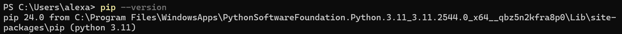

En caso de no tener PIP instalado, se pueden seguir los [pasos de instalación de la página oficial](https://pip.pypa.io/en/stable/installation/).

## 6.5. Gestión de paquetes

### 6.5.1. Instalación de un paquete con pip

Para instalar un paquete, simplemente use el comando `pip install` seguido del nombre del paquete. Por ejemplo, para instalar la popular librería 'requests', se usaría el siguiente comando:

```
>pip install requests
```

### 6.5.2. Actualización de paquetes con pip

Para actualizar un paquete, utilice el comando `pip install --upgrade` seguido del nombre del paquete. He aquí un ejemplo para actualizar la librería anteriormente descargada:

```
>pip install --upgrade requests
```

### 6.5.3. ¿Cómo utilizar un paquete?

Para utilizar un paquete instalado, se puede importar **al código de Python** mediante la palabra `import`seguido del nombre del paquete. Esto nos permite utilizarlo en funciones, métodos, etc. de este paquete. Si quisiéramos usar la librería instalada:

```
import requests
```

### 6.5.4. Desinstalar paquetes con pip

Para desinstalar un paquete, use el comando `pip uninstall` seguido del nombre del paquete. He aquí un ejemplo desinstalando la librería 'requests':

```
>pip uninstall requests
```

### 6.5.5. Listado de paquetes instalados

Con el comando `pip list` podemos listar los paquetes con su nombre y versión:

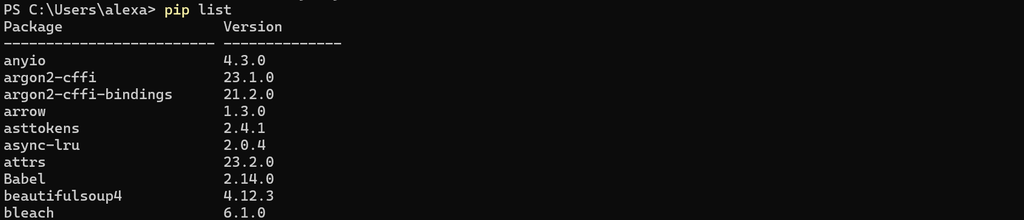

## 6.6. Bibliografía útil

- [pip (Documentación oficial del paquete)](https://pypi.org/project/pip/)
- [What is Pip? Guide to Python’s Package Installer](https://ioflood.com/blog/what-is-pip/#Basic_Package_Management_with_PIP)